# Mini Data Science Project #2 - Video Games Analysis

Tia Sindhu

**Delete this code block before submitting**

You should delete and add cells as you see fit.

Don't forget to put written text in **markdown** cells. To change a cell from a code block to a markdown cell:

- Click on the cell you'd like to modify.
- Go to 'Cell' at the top of the page.
- Go to 'Cell Type' in the drop down menu and click on either 'Code' or 'Markdown'.

```python
#Imports here
import pandas as pd
import numpy as np
import seaborn as sns
import matplotlib.pyplot as plt
from sklearn.model_selection import train_test_split
import statsmodels.formula.api as smf
from sklearn.metrics import mean_squared_error
from sklearn.metrics import r2_score
from sklearn.preprocessing import StandardScaler
from sklearn.linear_model import Lasso, Ridge, ElasticNet
from sklearn.linear_model import LinearRegression
import warnings
```

## 1. Introduction

### Research Question

I want to explore data on a wide variety of video games to understand what factors most influence a game's success. The goal of this project is to build a predictive model that performs best when estimating Review Score for new or unseen games. By using information such as platform features (handheld, multiplayer, online support), gameplay length statistics, genre, publisher, and licensing status, we can gain insights into what makes a game highly rated. With our best-performing model, we can also explore the relationships between these variables and identify the key drivers behind a game's critical reception.

### Research Motivation

Everyone loves playing video games. Whether we’re playing for fun, competing with our friends, or just to relax, we all have some games that we love. This project is interesting because it helps us understand what makes a game good in the eyes of reviewers. If we can predict review scores, game creators might be able to use that to make better games, and players can know which games might be worth checking out. It’s also just interesting to look at real data and find out what makes some games stand out more than others. Video games are prime in todays entertainment, influencing not just how we spend our free time, but also shaping trends in technology. Predicting a game’s potential success can help developers and publishers make informed decisions during production and marketing. For consumers, these insights could guide smarter purchase decisions. By analyzing a wide range of features — from playtime to platform characteristics — and building a predictive model of Review Score, I aim to discover what attributes are most associated with positively reviewed games. This can also benefit game studios aiming to optimize game design or target specific audience expectations.

## 2. Dataset Discussion

### Defintions:

Features.Max Players: the maximum number of players that can play the game at once

Features.Online?: whether the game supports online gameplay (True/False)

Metadata.Genres: the category or style of the game (e.g., Action, Sports, Strategy)

Metrics.Review Score: average critic review score for the game (out of 100)

Release.Year: the year the game was released

Metrics.Sales: the total number of units the game sold (in millions)

```python
df = pd.read_csv("video_games.csv")
df
```

|  | Title | Features.Handheld? | Features.Max Players | Features.Multiplatform? | Features.Online? | Metadata.Genres | Metadata.Licensed? | Metadata.Publishers | Metadata.Sequel? | Metrics.Review Score | ... | Length.Main + Extras.Average | Length.Main + Extras.Leisure | Length.Main + Extras.Median | Length.Main + Extras.Polled | Length.Main + Extras.Rushed | Length.Main Story.Average | Length.Main Story.Leisure | Length.Main Story.Median | Length.Main Story.Polled | Length.Main Story.Rushed |
| --- | --- | --- | --- | --- | --- | --- | --- | --- | --- | --- | --- | --- | --- | --- | --- | --- | --- | --- | --- | --- | --- |
| 0 | Super Mario 64 DS | True | 1 | True | True | Action | True | Nintendo | True | 85 | ... | 24.916667 | 29.966667 | 25.000000 | 16 | 18.333333 | 14.333333 | 18.316667 | 14.500000 | 21 | 9.700000 |
| 1 | Lumines: Puzzle Fusion | True | 1 | True | True | Strategy | True | Ubisoft | True | 89 | ... | 9.750000 | 9.866667 | 9.750000 | 2 | 9.616667 | 10.333333 | 11.083333 | 10.000000 | 3 | 9.583333 |
| 2 | WarioWare Touched! | True | 2 | True | True | Action,Racing / Driving,Sports | True | Nintendo | True | 81 | ... | 3.850000 | 5.666667 | 3.333333 | 11 | 2.783333 | 1.916667 | 2.933333 | 1.833333 | 30 | 1.433333 |
| 3 | Hot Shots Golf: Open Tee | True | 1 | True | True | Sports | True | Sony | True | 81 | ... | 0.000000 | 0.000000 | 0.000000 | 0 | 0.000000 | 0.000000 | 0.000000 | 0.000000 | 0 | 0.000000 |
| 4 | Spider-Man 2 | True | 1 | True | True | Action | True | Activision | True | 61 | ... | 12.766667 | 17.316667 | 12.500000 | 12 | 10.483333 | 8.350000 | 11.083333 | 8.000000 | 23 | 5.333333 |
| ... | ... | ... | ... | ... | ... | ... | ... | ... | ... | ... | ... | ... | ... | ... | ... | ... | ... | ... | ... | ... | ... |
| 1207 | Secret Files: Tunguska | True | 1 | True | True | Adventure | True | NaN | True | 71 | ... | 11.500000 | 11.750000 | 11.500000 | 2 | 11.250000 | 8.800000 | 12.566667 | 8.716667 | 16 | 6.816667 |
| 1208 | Fading Shadows | True | 1 | True | True | Action,Adventure | True | NaN | True | 62 | ... | 0.000000 | 0.000000 | 0.000000 | 0 | 0.000000 | 0.000000 | 0.000000 | 0.000000 | 0 | 0.000000 |
| 1209 | Hail to the Chimp | True | 1 | True | True | Action,Strategy | True | NaN | True | 51 | ... | 0.000000 | 0.000000 | 0.000000 | 0 | 0.000000 | 0.000000 | 0.000000 | 0.000000 | 0 | 0.000000 |
| 1210 | Secret Files: Tunguska | True | 2 | True | True | Adventure | True | NaN | True | 64 | ... | 11.500000 | 11.750000 | 11.500000 | 2 | 11.250000 | 8.800000 | 12.566667 | 8.716667 | 16 | 6.816667 |
| 1211 | Chicken Hunter | True | 1 | True | True | Action | True | NaN | True | 39 | ... | 0.000000 | 0.000000 | 0.000000 | 0 | 0.000000 | 0.000000 | 0.000000 | 0.000000 | 0 | 0.000000 |

1212 rows × 36 columns

```python
df.head()
```

|  | Title | Features.Handheld? | Features.Max Players | Features.Multiplatform? | Features.Online? | Metadata.Genres | Metadata.Licensed? | Metadata.Publishers | Metadata.Sequel? | Metrics.Review Score | ... | Length.Main + Extras.Average | Length.Main + Extras.Leisure | Length.Main + Extras.Median | Length.Main + Extras.Polled | Length.Main + Extras.Rushed | Length.Main Story.Average | Length.Main Story.Leisure | Length.Main Story.Median | Length.Main Story.Polled | Length.Main Story.Rushed |
| --- | --- | --- | --- | --- | --- | --- | --- | --- | --- | --- | --- | --- | --- | --- | --- | --- | --- | --- | --- | --- | --- |
| 0 | Super Mario 64 DS | True | 1 | True | True | Action | True | Nintendo | True | 85 | ... | 24.916667 | 29.966667 | 25.000000 | 16 | 18.333333 | 14.333333 | 18.316667 | 14.500000 | 21 | 9.700000 |
| 1 | Lumines: Puzzle Fusion | True | 1 | True | True | Strategy | True | Ubisoft | True | 89 | ... | 9.750000 | 9.866667 | 9.750000 | 2 | 9.616667 | 10.333333 | 11.083333 | 10.000000 | 3 | 9.583333 |
| 2 | WarioWare Touched! | True | 2 | True | True | Action,Racing / Driving,Sports | True | Nintendo | True | 81 | ... | 3.850000 | 5.666667 | 3.333333 | 11 | 2.783333 | 1.916667 | 2.933333 | 1.833333 | 30 | 1.433333 |
| 3 | Hot Shots Golf: Open Tee | True | 1 | True | True | Sports | True | Sony | True | 81 | ... | 0.000000 | 0.000000 | 0.000000 | 0 | 0.000000 | 0.000000 | 0.000000 | 0.000000 | 0 | 0.000000 |
| 4 | Spider-Man 2 | True | 1 | True | True | Action | True | Activision | True | 61 | ... | 12.766667 | 17.316667 | 12.500000 | 12 | 10.483333 | 8.350000 | 11.083333 | 8.000000 | 23 | 5.333333 |

5 rows × 36 columns

```python
df.shape[0]
```

```
1212
```

### Dataset Source

This dataset was taken and downloaded from CORGIS-edu on March 31st 2025. https://corgis-edu.github.io/corgis/csv/video_games/

## 3. Dataset Cleaning

### Initial Cleaning

First, we'd like to drop the Title column from the dataset. While the game title is useful for identification, it doesn't help us when predicting numeric outcomes like review score or modeling gameplay patterns. I also simplified the column names to make them easier to reference in code and to help describe the information each column holds.

```python
df1 = df.drop(['Title'], axis=1)
```

```python
df2 = df1.rename(columns={
    'Features.Handheld?': 'Handheld',
    'Features.Max Players': 'Max_Players',
    'Features.Multiplatform?': 'Multiplatform',
    'Features.Online?': 'Online',
    'Metadata.Genres': 'Genres',
    'Metadata.Licensed?': 'Licensed',
    'Metadata.Publishers': 'Publisher',
    'Metadata.Sequel?': 'Sequel',
    'Metrics.Review Score': 'Review_Score',
    'Metrics.Sales': 'Sales',
    'Metrics.Used Price': 'Used_Price',
    'Length.All PlayStyles.Average': 'Avg_All_PlayStyles',
    'Length.All PlayStyles.Leisure': 'Leisure_All_PlayStyles',
    'Length.All PlayStyles.Median': 'Median_All_PlayStyles',
    'Length.All PlayStyles.Polled': 'Polled_All_PlayStyles',
    'Length.All PlayStyles.Rushed': 'Rushed_All_PlayStyles',
    'Length.Completionists.Average': 'Avg_Completionists',
    'Length.Completionists.Leisure': 'Leisure_Completionists',
    'Length.Completionists.Median': 'Median_Completionists',
    'Length.Completionists.Polled': 'Polled_Completionists',
    'Length.Completionists.Rushed': 'Rushed_Completionists',
    'Length.Main + Extras.Average': 'Avg_Main_Extras',
    'Length.Main + Extras.Leisure': 'Leisure_Main_Extras',
    'Length.Main + Extras.Median': 'Median_Main_Extras',
    'Length.Main + Extras.Polled': 'Polled_Main_Extras',
    'Length.Main + Extras.Rushed': 'Rushed_Main_Extras',
    'Length.Main Story.Average': 'Avg_Main_Story',
    'Length.Main Story.Leisure': 'Leisure_Main_Story',
    'Length.Main Story.Median': 'Median_Main_Story',
    'Length.Main Story.Polled': 'Polled_Main_Story',
    'Length.Main Story.Rushed': 'Rushed_Main_Story',
})
```

```python
df2.head()
```

|  | Handheld | Max_Players | Multiplatform | Online | Genres | Licensed | Publisher | Sequel | Review_Score | Sales | ... | Avg_Main_Extras | Leisure_Main_Extras | Median_Main_Extras | Polled_Main_Extras | Rushed_Main_Extras | Avg_Main_Story | Leisure_Main_Story | Median_Main_Story | Polled_Main_Story | Rushed_Main_Story |
| --- | --- | --- | --- | --- | --- | --- | --- | --- | --- | --- | --- | --- | --- | --- | --- | --- | --- | --- | --- | --- | --- |
| 0 | True | 1 | True | True | Action | True | Nintendo | True | 85 | 4.69 | ... | 24.916667 | 29.966667 | 25.000000 | 16 | 18.333333 | 14.333333 | 18.316667 | 14.500000 | 21 | 9.700000 |
| 1 | True | 1 | True | True | Strategy | True | Ubisoft | True | 89 | 0.56 | ... | 9.750000 | 9.866667 | 9.750000 | 2 | 9.616667 | 10.333333 | 11.083333 | 10.000000 | 3 | 9.583333 |
| 2 | True | 2 | True | True | Action,Racing / Driving,Sports | True | Nintendo | True | 81 | 0.54 | ... | 3.850000 | 5.666667 | 3.333333 | 11 | 2.783333 | 1.916667 | 2.933333 | 1.833333 | 30 | 1.433333 |
| 3 | True | 1 | True | True | Sports | True | Sony | True | 81 | 0.49 | ... | 0.000000 | 0.000000 | 0.000000 | 0 | 0.000000 | 0.000000 | 0.000000 | 0.000000 | 0 | 0.000000 |
| 4 | True | 1 | True | True | Action | True | Activision | True | 61 | 0.45 | ... | 12.766667 | 17.316667 | 12.500000 | 12 | 10.483333 | 8.350000 | 11.083333 | 8.000000 | 23 | 5.333333 |

5 rows × 35 columns

### Missing Values

All of the variable data types in the video games dataset appear to make sense, most columns are either boolean, integers, floats, or strings (object). This means we can work with the dataset without needing to transform incompatible types before analysis. To check for missing data, I checked each column for null values. Almost all columns have complete data except the Publisher column, which contains 264 missing values. These may be games without a listed publisher, and we’ll need to decide whether to fill in these values, drop them, or exclude the column depending on our modeling goals.

```python
dtypes = df2.dtypes
dtypes
```

```
Handheld                     bool
Max_Players                 int64
Multiplatform                bool
Online                       bool
Genres                     object
Licensed                     bool
Publisher                  object
Sequel                       bool
Review_Score                int64
Sales                     float64
Used_Price                float64
Release.Console            object
Release.Rating             object
Release.Re-release?          bool
Release.Year                int64
Avg_All_PlayStyles        float64
Leisure_All_PlayStyles    float64
Median_All_PlayStyles     float64
Polled_All_PlayStyles       int64
Rushed_All_PlayStyles     float64
Avg_Completionists        float64
Leisure_Completionists    float64
Median_Completionists     float64
Polled_Completionists       int64
Rushed_Completionists     float64
Avg_Main_Extras           float64
Leisure_Main_Extras       float64
Median_Main_Extras        float64
Polled_Main_Extras          int64
Rushed_Main_Extras        float64
Avg_Main_Story            float64
Leisure_Main_Story        float64
Median_Main_Story         float64
Polled_Main_Story           int64
Rushed_Main_Story         float64
dtype: object
```

```python
df2.isna().sum()
```

```
Handheld                    0
Max_Players                 0
Multiplatform               0
Online                      0
Genres                      0
Licensed                    0
Publisher                 264
Sequel                      0
Review_Score                0
Sales                       0
Used_Price                  0
Release.Console             0
Release.Rating              0
Release.Re-release?         0
Release.Year                0
Avg_All_PlayStyles          0
Leisure_All_PlayStyles      0
Median_All_PlayStyles       0
Polled_All_PlayStyles       0
Rushed_All_PlayStyles       0
Avg_Completionists          0
Leisure_Completionists      0
Median_Completionists       0
Polled_Completionists       0
Rushed_Completionists       0
Avg_Main_Extras             0
Leisure_Main_Extras         0
Median_Main_Extras          0
Polled_Main_Extras          0
Rushed_Main_Extras          0
Avg_Main_Story              0
Leisure_Main_Story          0
Median_Main_Story           0
Polled_Main_Story           0
Rushed_Main_Story           0
dtype: int64
```

### Genre Cutoffs

Next, it would be reasonable to consider only popular genres in our dataset when building our predictive model. Some genres appear only a handful of times, which may not provide enough data to learn meaningful patterns. Looking at the value counts below, I decided to include only genres that appear at least 50 times in the dataset.

```python
df2['Genres'].value_counts()
```

```
Genres
Action                                                  476
Sports                                                  166
Strategy                                                 62
Action,Role-Playing (RPG)                                55
Racing / Driving                                         53
Role-Playing (RPG)                                       52
Action,Strategy                                          45
Action,Racing / Driving                                  40
Simulation                                               30
Action,Simulation                                        28
Action,Adventure                                         28
Adventure                                                21
Role-Playing (RPG),Strategy                              20
Action,Sports                                            20
Racing / Driving,Sports                                  19
Simulation,Strategy                                      12
Racing / Driving,Simulation,Sports                        9
Racing / Driving,Simulation                               6
Adventure,Simulation                                      6
Action,Racing / Driving,Sports                            6
Action,Simulation,Sports                                  6
Action,Role-Playing (RPG),Strategy                        5
Role-Playing (RPG),Simulation                             5
Action,Adventure,Role-Playing (RPG)                       4
Adventure,Role-Playing (RPG)                              4
Simulation,Sports                                         3
Action,Racing / Driving,Role-Playing (RPG)                3
Action,Adventure,Racing / Driving                         3
Adventure,Role-Playing (RPG),Strategy                     2
Educational                                               2
Action,Simulation,Strategy                                2
Simulation,Sports,Strategy                                2
Action,Adventure,Racing / Driving,Sports                  2
Adventure,Simulation,Sports                               1
Action,Role-Playing (RPG),Simulation                      1
Action,Racing / Driving,Sports,Strategy                   1
Action,Educational                                        1
Racing / Driving,Simulation,Strategy                      1
Role-Playing (RPG),Simulation,Strategy                    1
Educational,Simulation                                    1
Educational,Strategy                                      1
Adventure,Educational,Strategy                            1
Educational,Sports                                        1
Action,Role-Playing (RPG),Simulation,Sports,Strategy      1
Action,Racing / Driving,Role-Playing (RPG),Strategy       1
Action,Racing / Driving,Simulation                        1
Sports,Strategy                                           1
Action,Adventure,Strategy                                 1
Name: count, dtype: int64
```

```python
counts = df2['Genres'].value_counts()
df3 = df2[df2['Genres'].isin(counts.index[counts >= 50])]
df3['Genres'].value_counts()
```

```
Genres
Action                       476
Sports                       166
Strategy                      62
Action,Role-Playing (RPG)     55
Racing / Driving              53
Role-Playing (RPG)            52
Name: count, dtype: int64
```

By filtering this way, we keep our model focused on the most frequent genres in the dataset. This helps reduce noise and prevents the model from trying to make predictions on categories with very limited data.

### Single Variable Outlier Inspection

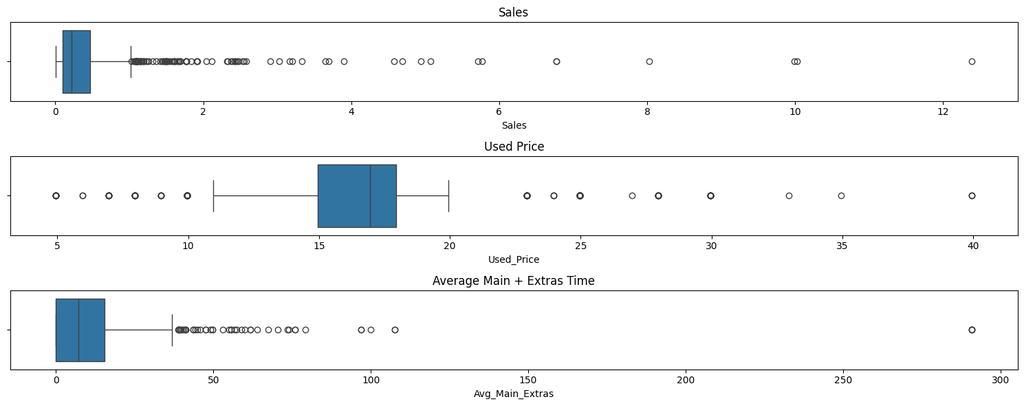

```python
fig, axes = plt.subplots(3, 1, figsize=(15, 6))

sns.boxplot(x='Sales', data=df3, ax=axes[0])
axes[0].set_title("Sales")

sns.boxplot(x='Used_Price', data=df3, ax=axes[1])
axes[1].set_title("Used Price")

sns.boxplot(x='Avg_Main_Extras', data=df3, ax=axes[2])
axes[2].set_title("Average Main + Extras Time")

plt.tight_layout()
plt.show()
```

Looking at each of our explanatory variables, the boxplots suggest that there are some outliers present, especially in numeric features like Sales, Used_Price, and Avg_Main_Extras. To reduce noise in our model, I applied a cutoff to the Avg_Main_Extras column, which contains data about how long it takes to complete the main story plus extras. Any value over 100 hours was considered an outlier and removed from the dataset.

```python
df4 = df3[df3['Avg_Main_Extras'] <= 100]
df3.shape[0] - df4.shape[0]
```

```
6
```

This means 6 data points were removed due to extreme playtime lengths.

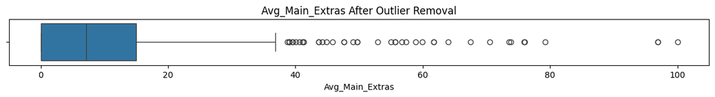

```python
plt.figure(figsize=(15, 1))
sns.boxplot(x='Avg_Main_Extras', data=df4)
plt.title("Avg_Main_Extras After Outlier Removal")
plt.show()
```

### Categorical Variable Inspection

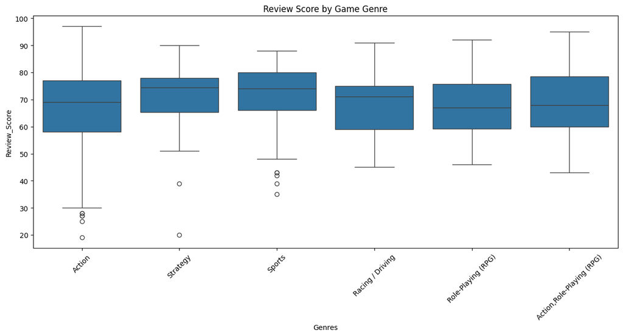

```python
plt.figure(figsize=(15, 6))
sns.boxplot(x='Genres', y='Review_Score', data=df4)
plt.xticks(rotation=45)
plt.title("Review Score by Game Genre")
plt.show()
```

## 4. Preliminary Analysis

### Variable Transformations

I explored several numeric variables — including Sales, Used_Price, and average playtime metrics — to examine their relationship with Review_Score. From the pairplot below, none of the features showed a strong linear correlation with review score. While some mild positive associations appear between longer games and higher scores, the trends are not strong enough to show strong transformations.

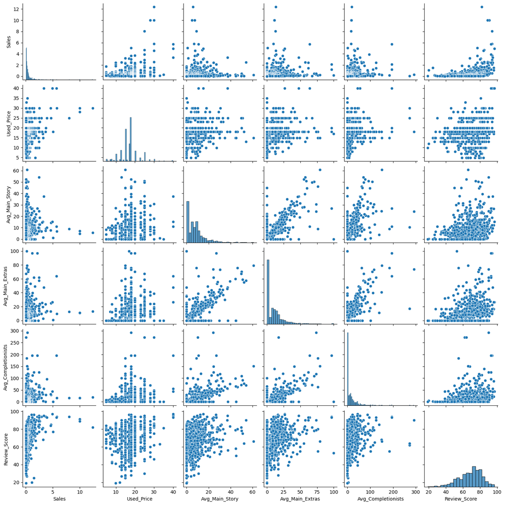

```python
numerical_columns = [
    'Sales', 'Used_Price', 'Avg_Main_Story', 'Avg_Main_Extras',
    'Avg_Completionists', 'Review_Score'
]

sns.pairplot(df4[numerical_columns])
plt.show()
```

The distributions also reveal strong skewness in some features — particularly Sales, which has a long right tail.

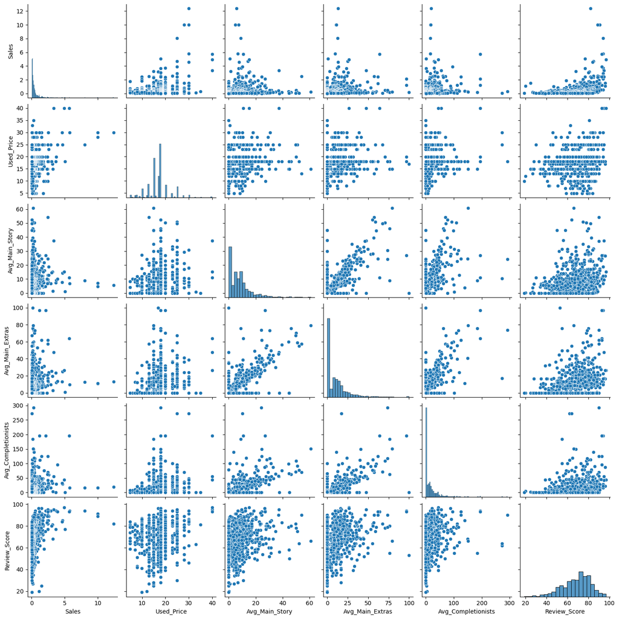

```python
sns.pairplot(df4[['Sales', 'Used_Price', 'Avg_Main_Story', 'Avg_Main_Extras',
                  'Avg_Completionists', 'Review_Score']])
plt.show()
```

## 5. Predictive Models

### Model Preperation

```python
df_num = df4[['Review_Score', 'Sales', 'Used_Price', 'Avg_Main_Story', 'Avg_Main_Extras', 'Avg_Completionists']]
df_cat = pd.get_dummies(df4[['Genres']], drop_first=True, dtype=int)
```

```python
df_model = pd.concat([df_num, df_cat], axis=1)
df_model
```

|  | Review_Score | Sales | Used_Price | Avg_Main_Story | Avg_Main_Extras | Avg_Completionists | Genres_Action,Role-Playing (RPG) | Genres_Racing / Driving | Genres_Role-Playing (RPG) | Genres_Sports | Genres_Strategy |
| --- | --- | --- | --- | --- | --- | --- | --- | --- | --- | --- | --- |
| 0 | 85 | 4.69 | 24.95 | 14.333333 | 24.916667 | 29.766667 | 0 | 0 | 0 | 0 | 0 |
| 1 | 89 | 0.56 | 14.95 | 10.333333 | 9.750000 | 0.000000 | 0 | 0 | 0 | 0 | 1 |
| 3 | 81 | 0.49 | 12.95 | 0.000000 | 0.000000 | 0.000000 | 0 | 0 | 0 | 1 | 0 |
| 4 | 61 | 0.45 | 14.95 | 8.350000 | 12.766667 | 72.566667 | 0 | 0 | 0 | 0 | 0 |
| 6 | 88 | 0.36 | 19.95 | 0.616667 | 0.883333 | 1.250000 | 0 | 1 | 0 | 0 | 0 |
| ... | ... | ... | ... | ... | ... | ... | ... | ... | ... | ... | ... |
| 1202 | 56 | 0.04 | 17.95 | 19.600000 | 26.266667 | 40.366667 | 0 | 0 | 0 | 0 | 1 |
| 1204 | 58 | 0.03 | 11.95 | 5.183333 | 4.516667 | 5.050000 | 0 | 0 | 0 | 0 | 0 |
| 1205 | 70 | 0.03 | 14.95 | 3.333333 | 0.000000 | 0.000000 | 0 | 0 | 0 | 0 | 0 |
| 1206 | 67 | 0.03 | 12.95 | 9.650000 | 13.200000 | 13.133333 | 0 | 0 | 1 | 0 | 0 |
| 1211 | 39 | 0.02 | 17.95 | 0.000000 | 0.000000 | 1.500000 | 0 | 0 | 0 | 0 | 0 |

858 rows × 11 columns

```python
df_train, df_test = train_test_split(df_model, test_size=0.2, random_state=1)
```

### Scaling: Z-Score Transformation

```python
scaler = StandardScaler()
scaler_vars = scaler.fit_transform(df_train)
df_train_s = pd.DataFrame(scaler_vars, columns=df_train.columns)
df_train_s
```

|  | Review_Score | Sales | Used_Price | Avg_Main_Story | Avg_Main_Extras | Avg_Completionists | Genres_Action,Role-Playing (RPG) | Genres_Racing / Driving | Genres_Role-Playing (RPG) | Genres_Sports | Genres_Strategy |
| --- | --- | --- | --- | --- | --- | --- | --- | --- | --- | --- | --- |
| 0 | -1.192991 | -0.143741 | 0.210969 | -0.332648 | 0.438390 | 0.059291 | -0.268095 | -0.264958 | -0.252123 | -0.467410 | -0.286389 |
| 1 | -1.723971 | -0.335232 | -0.005361 | -0.370601 | -0.751653 | -0.558234 | -0.268095 | -0.264958 | -0.252123 | -0.467410 | -0.286389 |
| 2 | 0.324095 | -0.311296 | -1.519669 | -0.969867 | -0.751653 | -0.558234 | -0.268095 | -0.264958 | -0.252123 | -0.467410 | -0.286389 |
| 3 | 0.248240 | -0.287359 | -0.654350 | 0.887856 | 0.442963 | -0.558234 | -0.268095 | 3.774181 | -0.252123 | -0.467410 | -0.286389 |
| 4 | 0.324095 | 1.172762 | 0.210969 | -0.011042 | -0.751653 | -0.558234 | -0.268095 | -0.264958 | -0.252123 | -0.467410 | -0.286389 |
| ... | ... | ... | ... | ... | ... | ... | ... | ... | ... | ... | ... |
| 681 | -0.434448 | -0.203582 | -0.221691 | -0.969867 | -0.751653 | -0.558234 | -0.268095 | -0.264958 | -0.252123 | 2.139448 | -0.286389 |
| 682 | 0.172386 | -0.383105 | 0.210969 | 0.947783 | -0.751653 | 1.062982 | -0.268095 | 3.774181 | -0.252123 | -0.467410 | -0.286389 |
| 683 | -0.965428 | -0.347200 | -1.087009 | -0.824045 | -0.751653 | -0.558234 | -0.268095 | -0.264958 | -0.252123 | -0.467410 | -0.286389 |
| 684 | -1.723971 | -0.407041 | -0.438020 | -0.889965 | -0.751653 | -0.558234 | -0.268095 | -0.264958 | -0.252123 | -0.467410 | -0.286389 |
| 685 | -0.131031 | -0.107836 | -0.438020 | 0.030907 | 0.124018 | 1.892729 | -0.268095 | -0.264958 | -0.252123 | -0.467410 | -0.286389 |

686 rows × 11 columns

```python
scaler_vars_test = scaler.transform(df_test)
df_test_s = pd.DataFrame(scaler_vars_test, columns=df_test.columns)
df_test_s
```

|  | Review_Score | Sales | Used_Price | Avg_Main_Story | Avg_Main_Extras | Avg_Completionists | Genres_Action,Role-Playing (RPG) | Genres_Racing / Driving | Genres_Role-Playing (RPG) | Genres_Sports | Genres_Strategy |
| --- | --- | --- | --- | --- | --- | --- | --- | --- | --- | --- | --- |
| 0 | -1.572263 | -0.454914 | -0.870680 | -0.318665 | -0.751653 | -0.164189 | -0.268095 | -0.264958 | -0.252123 | -0.467410 | -0.286389 |
| 1 | 0.399949 | -0.251455 | 0.643628 | -0.582342 | -0.751653 | -0.558234 | -0.268095 | -0.264958 | -0.252123 | -0.467410 | 3.491749 |
| 2 | 0.172386 | -0.347200 | 0.210969 | 0.887856 | 0.442963 | -0.558234 | -0.268095 | 3.774181 | -0.252123 | -0.467410 | -0.286389 |
| 3 | -0.055177 | -0.419009 | 0.210969 | -0.969867 | -0.751653 | -0.558234 | -0.268095 | -0.264958 | -0.252123 | -0.467410 | -0.286389 |
| 4 | 0.475803 | -0.526723 | 1.725277 | -0.730160 | -0.751653 | -0.558234 | -0.268095 | -0.264958 | -0.252123 | -0.467410 | -0.286389 |
| ... | ... | ... | ... | ... | ... | ... | ... | ... | ... | ... | ... |
| 167 | -1.041283 | -0.454914 | 0.210969 | -0.070968 | 1.083139 | -0.051604 | -0.268095 | -0.264958 | -0.252123 | -0.467410 | -0.286389 |
| 168 | 0.703366 | -0.287359 | 0.643628 | 0.228664 | 0.277203 | 1.130533 | -0.268095 | 3.774181 | -0.252123 | -0.467410 | -0.286389 |
| 169 | -0.510303 | -0.502787 | 2.806925 | 0.258628 | 0.432674 | 8.645545 | -0.268095 | -0.264958 | -0.252123 | -0.467410 | -0.286389 |
| 170 | -2.330806 | -0.383105 | -1.087009 | 0.334535 | -0.751653 | -0.558234 | -0.268095 | -0.264958 | -0.252123 | -0.467410 | -0.286389 |
| 171 | -0.965428 | -0.383105 | -0.438020 | -0.969867 | 0.129733 | -0.558234 | -0.268095 | -0.264958 | -0.252123 | 2.139448 | -0.286389 |

172 rows × 11 columns

### 5.1. Non-Regularized Linear Regression Full Model

```python
nonreg_model = smf.ols('Review_Score ~ Sales + Used_Price + Avg_Main_Story + Avg_Main_Extras + Avg_Completionists', data=df_train_s).fit()
y_test = df_test_s['Review_Score']
y_pred = nonreg_model.predict(df_test_s)
r2_nonreg = r2_score(y_test, y_pred)
r2_nonreg
```

```
0.0011662805026779743
```

### 5.2. Non-Regularized Linear Regression Full Model with Interaction Terms

```python
formula_interaction = 'Review_Score ~ Sales * Used_Price + Avg_Main_Story + Avg_Main_Extras + Avg_Completionists'
nonreg_model_inter = smf.ols(formula_interaction, data=df_train_s).fit()
y_pred_inter = nonreg_model_inter.predict(df_test_s)
r2_inter = r2_score(y_test, y_pred_inter)
r2_inter
```

```
0.0448753249901086
```

### 5.3. Regularization

```python
X_train = df_train.drop(columns=['Review_Score'])
X_test = df_test.drop(columns=['Review_Score'])
y_train = df_train['Review_Score']
y_test = df_test['Review_Score']
```

```python
lasso_list = []
for alpha in np.arange(0, 0.8005, 0.005):
    mod = Lasso(alpha=alpha, max_iter=10000)
    mod.fit(X_train, y_train)
    r2 = mod.score(X_test, y_test)
    lasso_list.append((alpha, r2))

df_lasso = pd.DataFrame(lasso_list, columns=['lambda', 'test_r2'])
best_lasso = df_lasso.sort_values(by='test_r2', ascending=False).head(1)
best_lasso
```

|  | lambda | test_r2 |
| --- | --- | --- |
| 0 | 0.0 | 0.115267 |

```python
ridge_list = []
for alpha in np.arange(0, 501, 1):
    mod = Ridge(alpha=alpha, max_iter=10000)
    mod.fit(X_train, y_train)
    r2 = mod.score(X_test, y_test)
    ridge_list.append((alpha, r2))

df_ridge = pd.DataFrame(ridge_list, columns=['lambda', 'test_r2'])
best_ridge = df_ridge.sort_values(by='test_r2', ascending=False).head(1)
best_ridge
```

|  | lambda | test_r2 |
| --- | --- | --- |
| 0 | 0 | 0.115267 |

```python
en_list = []
for alpha in np.arange(0, 0.8005, 0.005):
    mod = ElasticNet(alpha=alpha, l1_ratio=0.7, max_iter=10000)
    mod.fit(X_train, y_train)
    r2 = mod.score(X_test, y_test)
    en_list.append((alpha, r2))

df_en = pd.DataFrame(en_list, columns=['lambda', 'test_r2'])
best_en = df_en.sort_values(by='test_r2', ascending=False).head(1)
best_en
```

|  | lambda | test_r2 |
| --- | --- | --- |
| 0 | 0.0 | 0.115267 |

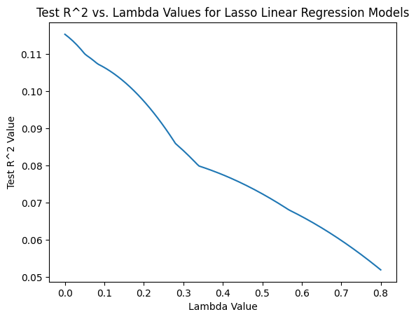

```python
plt.title('Test R^2 vs. Lambda Values for Lasso Linear Regression Models')
plt.plot(df_lasso['lambda'].values, df_lasso['test_r2'].values)
plt.ylabel('Test R^2 Value')
plt.xlabel('Lambda Value')
plt.show()
```

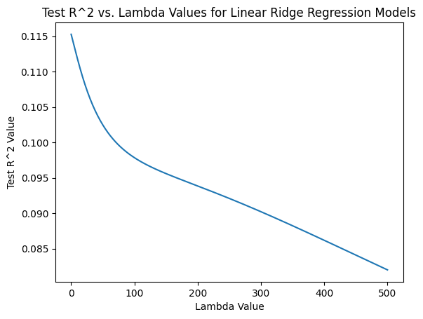

```python
plt.title('Test R^2 vs. Lambda Values for Linear Ridge Regression Models')
plt.plot(df_ridge['lambda'].values, df_ridge['test_r2'].values)
plt.ylabel('Test R^2 Value')
plt.xlabel('Lambda Value')
plt.show()
```

## 6. Best Model Discussion

#### Slope Interpretations

Average Playtime

## 7. Conclusion

### Future Work

To improve the model further, future analysis could include additional features such as marketing budget, user vs. critic score breakdowns, or social media. Exploring non-linear models or other methods could also help catch more interactions within the variable. Finally, expanding the dataset to include more recent games or additional platforms may help ensure the model remains relevant and generalizable.